# SN_01_LTD_RECIP_ADDR_STATE

Recipient state · Code report

## Overview

**Description**

Province or state

**Table**

`SN-P01-T01-LIQUIDATION-TERMINATION-DISSOLUTION` (many)

**Location code**

`SCHED-N-PART-01-LINE-01-COL-F`

**Family**

`SCHED-N-PART-01-LINE-01-COL-F` · siblings: SN_01_LTD_RECIP_ADDR_CITY, SN_01_LTD_RECIP_ADDR_CNTR, SN_01_LTD_RECIP_ADDR_L1, SN_01_LTD_RECIP_ADDR_L2, SN_01_LTD_RECIP_ADDR_ZIP, SN_01_LTD_RECIP_NAME_ORG_L1

**Data type**

text (xsd: , TextType, StateType)

**Scope**

PZ

**Status**

unreviewed

10

xpaths mapped (6 observed)

30,346

filings with a value

2009–2024

tax years observed

9

open flags (1 errors)

## Flags

| Severity | Flag | Xpath | Detail |
| --- | --- | --- | --- |
| ⚠ error | `COLLISION` | IRS990ScheduleN/LiquidationOfAssetsTableGrp/LiquidationOfAssetsDetail/ForeignAddress/ProvinceOrStateNm | 34 filings contain 2+ of its xpaths; most common set: /Return/ReturnData/IRS990ScheduleN/LiquidationOfAssetsTableGrp/LiquidationOfAssetsDetail/ForeignAddress/ProvinceOrStateNm ; /Return/ReturnData/IRS… |
| ⓘ info | `MANY_NOT_REPEATING` | IRS990ScheduleN/LiquidationOfAssetsTableGrp/LiquidationOfAssetsDetail/USAddress/StateAbbreviationCd | many-to-one table, but 66% of values sit in no repeating element |
| ⓘ info | `MANY_NOT_REPEATING` | IRS990ScheduleN/LiquidationTable/LiquidationDetail/AddressUS/State | many-to-one table, but 63% of values sit in no repeating element |
| ⓘ info | `MANY_NOT_REPEATING` | IRS990ScheduleN/LiquidationOfAssetsTableGrp/LiquidationOfAssetsDetail/USAddress/State | many-to-one table, but 61% of values sit in no repeating element |
| ⓘ info | `MANY_NOT_REPEATING` | IRS990ScheduleN/LiquidationOfAssetsTableGrp/LiquidationOfAssetsDetail/ForeignAddress/ProvinceOrStateNm | many-to-one table, but 58% of values sit in no repeating element |
| ⓘ info | `UNOBSERVED` | IRS990ScheduleN/Form990ScheduleNPartI/LiquidationTable/AddressForeign/ProvinceOrState | never observed in TY2009-2024 filings |
| ⓘ info | `UNOBSERVED` | IRS990ScheduleN/Form990ScheduleNPartI/LiquidationTable/AddressUS/State | never observed in TY2009-2024 filings |
| ⓘ info | `UNOBSERVED` | IRS990ScheduleN/LiquidationTable/AddressForeign/ProvinceOrState | never observed in TY2009-2024 filings |
| ⓘ info | `UNOBSERVED` | IRS990ScheduleN/LiquidationTable/AddressUS/State | never observed in TY2009-2024 filings |

## Xpaths

All mapped xpaths (under /Return/ReturnData or /Return/ReturnHeader), oldest first. Charts label each series by its xpath.

| Xpath | Form | Chart label | First year | Last year | Versions | Filings | Repeats in |
| --- | --- | --- | --- | --- | --- | --- | --- |
| IRS990ScheduleN/LiquidationTable/LiquidationDetail/AddressUS/State | Sched N | …eduleN/LiquidationTable/LiquidationDetail/AddressUS/State | 2009 | 2012 | 16 | 2,980 | 36.3% |
| IRS990ScheduleN/LiquidationTable/LiquidationDetail/AddressForeign/ProvinceOrState | Sched N | …ionTable/LiquidationDetail/AddressForeign/ProvinceOrState | 2011 | 2012 | 3 | 5 | 20.0% |
| IRS990ScheduleN/LiquidationOfAssetsTableGrp/LiquidationOfAssetsDetail/USAddress/State | Sched N | …fAssetsTableGrp/LiquidationOfAssetsDetail/USAddress/State | 2013 | 2013 | 3 | 1,429 | 37.9% |
| IRS990ScheduleN/LiquidationOfAssetsTableGrp/LiquidationOfAssetsDetail/ForeignAddress/ProvinceOrState | Sched N | …/LiquidationOfAssetsDetail/ForeignAddress/ProvinceOrState | 2013 | 2013 | 2 | 2 | 50.0% |
| IRS990ScheduleN/LiquidationOfAssetsTableGrp/LiquidationOfAssetsDetail/USAddress/StateAbbreviationCd | Sched N | …p/LiquidationOfAssetsDetail/USAddress/StateAbbreviationCd | 2014 | 2024 | 34 | 25,817 | 33.7% |
| IRS990ScheduleN/LiquidationOfAssetsTableGrp/LiquidationOfAssetsDetail/ForeignAddress/ProvinceOrStateNm | Sched N | …iquidationOfAssetsDetail/ForeignAddress/ProvinceOrStateNm | 2014 | 2024 | 22 | 113 | 22.1% |
| IRS990ScheduleN/Form990ScheduleNPartI/LiquidationTable/AddressForeign/ProvinceOrState | Sched N | …uleNPartI/LiquidationTable/AddressForeign/ProvinceOrState |  |  |  | 0 |  |
| IRS990ScheduleN/Form990ScheduleNPartI/LiquidationTable/AddressUS/State | Sched N | Other |  |  |  | 0 |  |
| IRS990ScheduleN/LiquidationTable/AddressForeign/ProvinceOrState | Sched N | Other |  |  |  | 0 |  |
| IRS990ScheduleN/LiquidationTable/AddressUS/State | Sched N | Other |  |  |  | 0 |  |

## Coverage

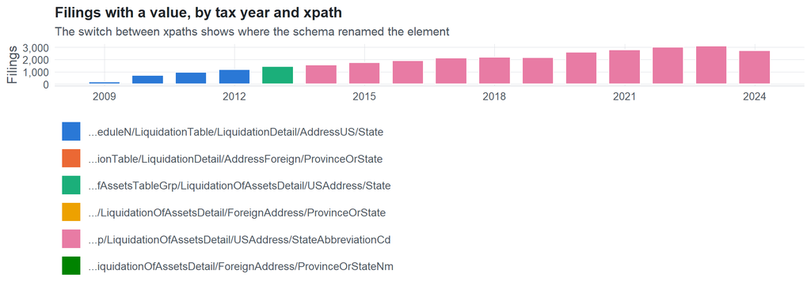

**Table view**

Table view: filings by tax year and series

| Tax year | …eduleN/LiquidationTable/LiquidationDetail/AddressUS/State | …ionTable/LiquidationDetail/AddressForeign/ProvinceOrState | …fAssetsTableGrp/LiquidationOfAssetsDetail/USAddress/State | …/LiquidationOfAssetsDetail/ForeignAddress/ProvinceOrState | …p/LiquidationOfAssetsDetail/USAddress/StateAbbreviationCd | …iquidationOfAssetsDetail/ForeignAddress/ProvinceOrStateNm |
| --- | --- | --- | --- | --- | --- | --- |
| 2009 | 164 | 0 | 0 | 0 | 0 | 0 |
| 2010 | 689 | 0 | 0 | 0 | 0 | 0 |
| 2011 | 951 | 2 | 0 | 0 | 0 | 0 |
| 2012 | 1,176 | 3 | 0 | 0 | 0 | 0 |
| 2013 | 0 | 0 | 1,429 | 2 | 0 | 0 |
| 2014 | 0 | 0 | 0 | 0 | 1,557 | 5 |
| 2015 | 0 | 0 | 0 | 0 | 1,751 | 6 |
| 2016 | 0 | 0 | 0 | 0 | 1,886 | 4 |
| 2017 | 0 | 0 | 0 | 0 | 2,128 | 8 |
| 2018 | 0 | 0 | 0 | 0 | 2,180 | 6 |
| 2019 | 0 | 0 | 0 | 0 | 2,153 | 6 |
| 2020 | 0 | 0 | 0 | 0 | 2,601 | 7 |
| 2021 | 0 | 0 | 0 | 0 | 2,764 | 18 |
| 2022 | 0 | 0 | 0 | 0 | 3,011 | 13 |
| 2023 | 0 | 0 | 0 | 0 | 3,096 | 19 |
| 2024 | 0 | 0 | 0 | 0 | 2,690 | 21 |

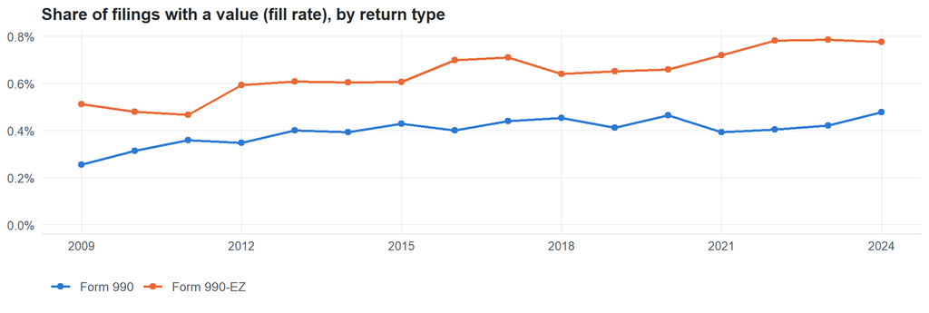

**Table view**

Table view: fill rate

| Tax year | Return type | Filings | All filings | Fill rate |
| --- | --- | --- | --- | --- |
| 2009 | Form 990 | 85 | 33,311 | 0.26% |
| 2009 | Form 990-EZ | 79 | 15,470 | 0.51% |
| 2010 | Form 990 | 385 | 123,025 | 0.31% |
| 2010 | Form 990-EZ | 304 | 63,326 | 0.48% |
| 2011 | Form 990 | 571 | 159,504 | 0.36% |
| 2011 | Form 990-EZ | 382 | 82,048 | 0.47% |
| 2012 | Form 990 | 623 | 179,688 | 0.35% |
| 2012 | Form 990-EZ | 556 | 93,750 | 0.59% |
| 2013 | Form 990 | 796 | 198,855 | 0.40% |
| 2013 | Form 990-EZ | 635 | 104,375 | 0.61% |
| 2014 | Form 990 | 860 | 218,619 | 0.39% |
| 2014 | Form 990-EZ | 702 | 116,417 | 0.60% |
| 2015 | Form 990 | 1,001 | 233,519 | 0.43% |
| 2015 | Form 990-EZ | 756 | 124,894 | 0.61% |
| 2016 | Form 990 | 978 | 243,903 | 0.40% |
| 2016 | Form 990-EZ | 912 | 130,484 | 0.70% |
| 2017 | Form 990 | 1,149 | 261,612 | 0.44% |
| 2017 | Form 990-EZ | 987 | 139,144 | 0.71% |
| 2018 | Form 990 | 1,230 | 271,442 | 0.45% |
| 2018 | Form 990-EZ | 956 | 149,384 | 0.64% |
| 2019 | Form 990 | 1,165 | 283,694 | 0.41% |
| 2019 | Form 990-EZ | 994 | 152,622 | 0.65% |
| 2020 | Form 990 | 1,489 | 320,342 | 0.46% |
| 2020 | Form 990-EZ | 1,119 | 169,864 | 0.66% |
| 2021 | Form 990 | 1,323 | 336,480 | 0.39% |
| 2021 | Form 990-EZ | 1,459 | 202,724 | 0.72% |
| 2022 | Form 990 | 1,413 | 349,055 | 0.40% |
| 2022 | Form 990-EZ | 1,611 | 206,130 | 0.78% |
| 2023 | Form 990 | 1,494 | 354,768 | 0.42% |
| 2023 | Form 990-EZ | 1,621 | 206,379 | 0.79% |
| 2024 | Form 990 | 1,324 | 277,298 | 0.48% |
| 2024 | Form 990-EZ | 1,387 | 178,867 | 0.78% |

## Repeating groups

Table cardinality in the concordance: **many**. 6 of 6 observed xpaths repeat within a filing.

Repeating element each xpath was observed in (from the raw indexed xpath)

| Xpath | Repeating element | Filings (summed over years) |
| --- | --- | --- |
| IRS990ScheduleN/LiquidationTable/LiquidationDetail/AddressUS/State | (none) | 1877 |
| IRS990ScheduleN/LiquidationTable/LiquidationDetail/AddressUS/State | IRS990ScheduleN/LiquidationTable/LiquidationDetail | 1103 |
| IRS990ScheduleN/LiquidationTable/LiquidationDetail/AddressForeign/ProvinceOrState | (none) | 2 |
| IRS990ScheduleN/LiquidationTable/LiquidationDetail/AddressForeign/ProvinceOrState | IRS990ScheduleN/LiquidationTable/LiquidationDetail | 3 |
| IRS990ScheduleN/LiquidationOfAssetsTableGrp/LiquidationOfAssetsDetail/ForeignAddress/ProvinceOrState | IRS990ScheduleN/LiquidationOfAssetsTableGrp/LiquidationOfAssetsDetail | 2 |
| IRS990ScheduleN/LiquidationOfAssetsTableGrp/LiquidationOfAssetsDetail/USAddress/State | (none) | 869 |
| IRS990ScheduleN/LiquidationOfAssetsTableGrp/LiquidationOfAssetsDetail/USAddress/State | IRS990ScheduleN/LiquidationOfAssetsTableGrp/LiquidationOfAssetsDetail | 560 |
| IRS990ScheduleN/LiquidationOfAssetsTableGrp/LiquidationOfAssetsDetail/ForeignAddress/ProvinceOrStateNm | (none) | 65 |
| IRS990ScheduleN/LiquidationOfAssetsTableGrp/LiquidationOfAssetsDetail/ForeignAddress/ProvinceOrStateNm | IRS990ScheduleN/LiquidationOfAssetsTableGrp/LiquidationOfAssetsDetail | 48 |
| IRS990ScheduleN/LiquidationOfAssetsTableGrp/LiquidationOfAssetsDetail/USAddress/StateAbbreviationCd | (none) | 16933 |
| IRS990ScheduleN/LiquidationOfAssetsTableGrp/LiquidationOfAssetsDetail/USAddress/StateAbbreviationCd | IRS990ScheduleN/LiquidationOfAssetsTableGrp/LiquidationOfAssetsDetail | 8884 |

## Values

| Result | Check | Detail |
| --- | --- | --- |
| ✓ pass | Small code list | up to 60 distinct values per xpath and year |
| ✓ pass | Codes share one format | 100% have the shape AA |
| ✓ pass | Consistent letter case | 0.0% of values are lower case |

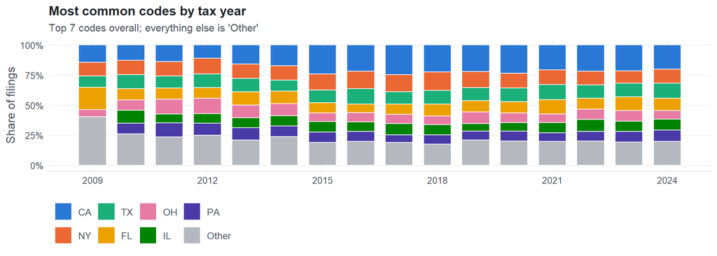

**Table view**

Table view: filings by code and tax year

| tax_year | CA | NY | TX | FL | OH | IL | PA | Other |
| --- | --- | --- | --- | --- | --- | --- | --- | --- |
| 2009 | 14 | 11 | 9 | 18 | 6 | 0 | 0 | 39 |
| 2010 | 48 | 44 | 44 | 35 | 32 | 41 | 33 | 98 |
| 2011 | 71 | 61 | 51 | 48 | 63 | 37 | 60 | 121 |
| 2012 | 71 | 84 | 72 | 58 | 82 | 51 | 64 | 160 |
| 2013 | 123 | 92 | 86 | 86 | 82 | 65 | 79 | 162 |
| 2014 | 147 | 102 | 76 | 91 | 85 | 71 | 77 | 202 |
| 2015 | 243 | 136 | 106 | 85 | 72 | 89 | 87 | 191 |
| 2016 | 229 | 152 | 134 | 74 | 82 | 81 | 88 | 208 |
| 2017 | 298 | 170 | 124 | 100 | 94 | 111 | 77 | 228 |
| 2018 | 288 | 196 | 145 | 128 | 92 | 107 | 98 | 227 |
| 2019 | 270 | 162 | 131 | 114 | 119 | 76 | 88 | 257 |
| 2020 | 353 | 181 | 172 | 139 | 118 | 108 | 123 | 300 |
| 2021 | 321 | 191 | 196 | 183 | 113 | 131 | 111 | 308 |
| 2022 | 350 | 184 | 179 | 148 | 137 | 158 | 128 | 325 |
| 2023 | 378 | 185 | 200 | 198 | 158 | 150 | 155 | 341 |
| 2024 | 315 | 184 | 196 | 161 | 113 | 141 | 147 | 312 |

Code frequencies (all xpaths, all years)

| Code | Filings | Share |
| --- | --- | --- |
| CA | 3,519 | 20.7% |
| NY | 2,135 | 12.6% |
| TX | 1,921 | 11.3% |
| FL | 1,666 | 9.8% |
| OH | 1,448 | 8.5% |
| IL | 1,417 | 8.3% |
| PA | 1,415 | 8.3% |
| VA | 709 | 4.2% |
| MA | 698 | 4.1% |
| MI | 651 | 3.8% |
| CO | 604 | 3.6% |
| NC | 159 | 0.9% |
| WI | 147 | 0.9% |
| NJ | 126 | 0.7% |
| DC | 88 | 0.5% |
| WA | 85 | 0.5% |
| IN | 75 | 0.4% |
| MO | 33 | 0.2% |
| ONTARIO | 7 | 0.0% |
| IA | 6 | 0.0% |
| BC | 3 | 0.0% |
| LONDON | 2 | 0.0% |
| Ontario | 2 | 0.0% |
| QUEBEC | 2 | 0.0% |
| ADDIS ABABA | 2 | 0.0% |
| Gujarat | 2 | 0.0% |
| JERUSALEM | 2 | 0.0% |
| London | 2 | 0.0% |
| ALBERTA | 1 | 0.0% |
| Ption-Ville | 1 | 0.0% |

First rows shown.

## Examples

| Tax year | Return | Xpath | Organization | Value | Source |
| --- | --- | --- | --- | --- | --- |
| 2024 | 990EZ | IRS990ScheduleN/LiquidationOfAssetsTableGrp/LiquidationOfAssetsDetail/ForeignAddress/ProvinceOrStateNm | ROYAL COLLEGE OF ART USA INC | London | [XML](https://gt990datalake-rawdata.s3.amazonaws.com/EfileData/XmlFiles/202503169349200710_public.xml) |
| 2024 | 990 | IRS990ScheduleN/LiquidationOfAssetsTableGrp/LiquidationOfAssetsDetail/USAddress/StateAbbreviationCd | BIG BROTHERS BIG SISTERS OF ISLAND COUNTY | WA | [XML](https://gt990datalake-rawdata.s3.amazonaws.com/EfileData/XmlFiles/202620289349301652_public.xml) |
| 2023 | 990EZ | IRS990ScheduleN/LiquidationOfAssetsTableGrp/LiquidationOfAssetsDetail/ForeignAddress/ProvinceOrStateNm | BELIZE ACUTE CARE & TRAUMA SURGERY | COROZAL | [XML](https://gt990datalake-rawdata.s3.amazonaws.com/EfileData/XmlFiles/202443099349201639_public.xml) |
| 2023 | 990EZ | IRS990ScheduleN/LiquidationOfAssetsTableGrp/LiquidationOfAssetsDetail/USAddress/StateAbbreviationCd | CAREGIVERS JOURNAL | UT | [XML](https://gt990datalake-rawdata.s3.amazonaws.com/EfileData/XmlFiles/202400489349200020_public.xml) |
| 2022 | 990EZ | IRS990ScheduleN/LiquidationOfAssetsTableGrp/LiquidationOfAssetsDetail/ForeignAddress/ProvinceOrStateNm | GHANA COMMUNITY PATHWAYS | UER | [XML](https://gt990datalake-rawdata.s3.amazonaws.com/EfileData/XmlFiles/202301259349202115_public.xml) |
| 2022 | 990 | IRS990ScheduleN/LiquidationOfAssetsTableGrp/LiquidationOfAssetsDetail/USAddress/StateAbbreviationCd | ENERGY CONSUMER CONNECTION INC | NC | [XML](https://gt990datalake-rawdata.s3.amazonaws.com/EfileData/XmlFiles/202302899349303665_public.xml) |
| 2021 | 990 | IRS990ScheduleN/LiquidationOfAssetsTableGrp/LiquidationOfAssetsDetail/ForeignAddress/ProvinceOrStateNm | SPORTS WAGERING INTEGRITY | ELSTREE | [XML](https://gt990datalake-rawdata.s3.amazonaws.com/EfileData/XmlFiles/202232209349300028_public.xml) |
| 2021 | 990EZ | IRS990ScheduleN/LiquidationOfAssetsTableGrp/LiquidationOfAssetsDetail/USAddress/StateAbbreviationCd | GREATER CINCINNATI GOLF ASSOCIATION | OH | [XML](https://gt990datalake-rawdata.s3.amazonaws.com/EfileData/XmlFiles/202212359349200321_public.xml) |
| 2020 | 990 | IRS990ScheduleN/LiquidationOfAssetsTableGrp/LiquidationOfAssetsDetail/ForeignAddress/ProvinceOrStateNm | AMERICAN FRIENDS OF THE EDINBURGH INTERNATIONAL FESTIVAL | EDINBURGH | [XML](https://gt990datalake-rawdata.s3.amazonaws.com/EfileData/XmlFiles/202120909349300522_public.xml) |
| 2020 | 990 | IRS990ScheduleN/LiquidationOfAssetsTableGrp/LiquidationOfAssetsDetail/USAddress/StateAbbreviationCd | CHILD CENTER AND ADULT SERVICES INC | MD | [XML](https://gt990datalake-rawdata.s3.amazonaws.com/EfileData/XmlFiles/202101319349303150_public.xml) |
| 2019 | 990 | IRS990ScheduleN/LiquidationOfAssetsTableGrp/LiquidationOfAssetsDetail/ForeignAddress/ProvinceOrStateNm | COUNCIL FOR BIOTECHNOLOGY INFORMATION | BRUSSELS | [XML](https://gt990datalake-rawdata.s3.amazonaws.com/EfileData/XmlFiles/202013079349302201_public.xml) |
| 2019 | 990 | IRS990ScheduleN/LiquidationOfAssetsTableGrp/LiquidationOfAssetsDetail/USAddress/StateAbbreviationCd | PECOS VALLEY MEDICAL CENTER INC | NM | [XML](https://gt990datalake-rawdata.s3.amazonaws.com/EfileData/XmlFiles/202001619349301910_public.xml) |

## Reviewer checklist

- The definition matches the form line and instructions for every xpath’s schema years.
- Every xpath pooled here measures the same thing on the 990 and 990-EZ (close enough for analysis).
- The coverage chart has no unexplained gaps or jumps between tax years.
- Each open flag is fixed, or accepted with a note in validation_log.csv.
- Every code is valid for the list the form uses (state, country, valuation method, …).
- The code list and its meaning did not change across schema versions.
- Codes are stored as text, so values like leading zeros are preserved.

Record the review as a row in `inst/extdata/src/validation_log.csv` (variable_name, reviewer, date, status, note). Evidence built 2026-09-23 17:09:04 MST from the ef2 DuckDB builds (tax years 2009–2024).